# Sense of Coherence psychometrics

```r
library(tidyverse)
library(semTools)

set.seed(21)

knitr::opts_chunk$set(message=F,
                      warning=F)
```

Convinience functions

```r
# Do not print output when running function (does not work ;( )
quiet <- function(code){
  sink("NUL")
  tmp = code
  sink()
  return(tmp)
}

# Round numbers
round_trail <- function(string) sprintf("%.2f", round(string, 2))
```

## The Sense of Coherence scale

The iBerry cohort uses the 13-item version of Antonovsky’s Sense of Coherence (SOC) scale. Usually responses are scored on a five response options Likert scale, but iBerry has **modified it to use three response options** instead.

A *total score* is usually created from all 13 items, that is how Antonovsky argued. Despite the prescription to only use a total score, the concept of SOC is said to consist of three underlying subfactors that load onto the total score factor. Those subfactors correspond to:

- Comprehensibility (consist items: 2, 6, 8, 9, and 11);
- Manageability (items: 3, 5, 10, and 13);
- Meaningfulness (items: 1, 4, 7, and 12)

### Load data

There is full Sense of Coherence data available for 562 participants

```r
df_soc <-
  read_rds("bin/data_cleaned.rds") %>%
  select(soc_1:soc_13) %>%
  drop_na()
```

Item names by extracting the attributes of each column (the variable labels from SPSS)

Label attributes are extracted via `attribute(df[[col_name]])$label`

```r
# Load SPSS file
df_spss <-
  haven::read_spss("bin/soc.sav") %>%
  janitor::clean_names()

df_labels <-
  # Create a tibble with the SOC item column names
  tibble(item = names(df_soc)) %>%
  # Extract the attribute of each column name in the tibble
  mutate(label = map_chr(item, ~attributes(df_spss[[.]])$label),
         label = str_remove(label, "\\d+[.] "),
         subfactor = c("Me", "C", "Ma", "Me", "Ma", "C", "Me", "C", "C", "Ma", "C", "Me", "Ma"),
         subfactor = case_when(subfactor == "Me" ~ "Meaningfulness",
                               subfactor == "Ma" ~ "Manageability",
                               subfactor == "C" ~ "Comprehensibility"))
```

## Descriptives

The raw correlations between all items visualized as a network. The colours correposond to the subfactors as identified by Antonovsky, the author of the SOC scale. All items should positively correlate with each other as they do here indicated by all green connections (no red/negative assocations)

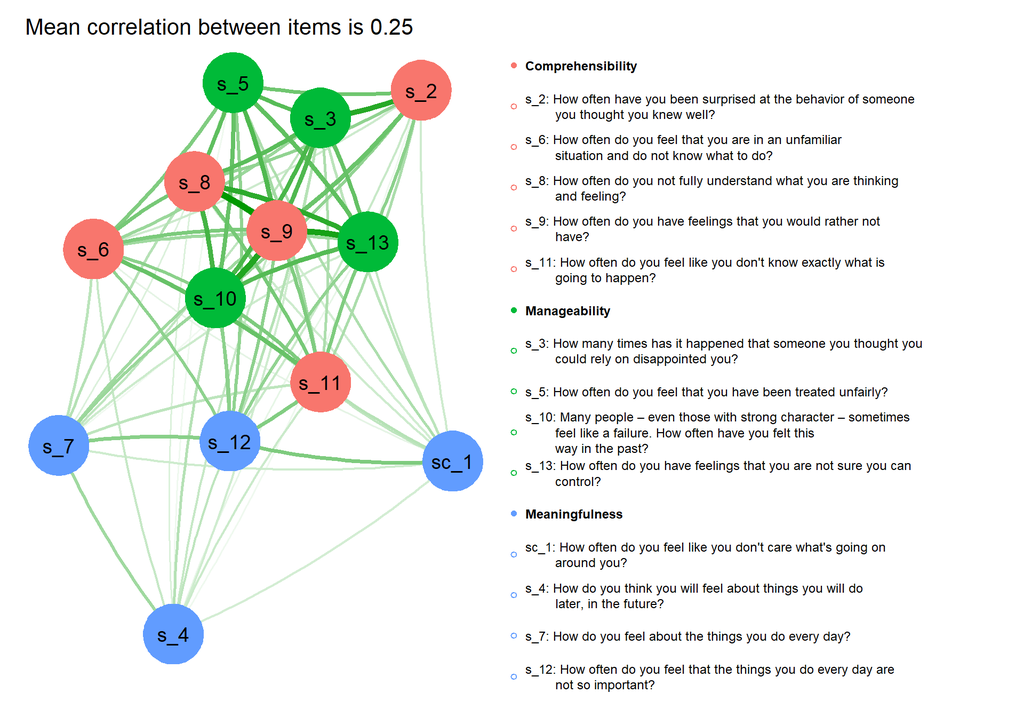

```r
mean_corr <-
  cor(df_soc) %>%
  qgraph::mat2vec() %>%
  mean()

qgraph::qgraph(cor(df_soc),
               nodeNames = str_wrap(df_labels$label, width = 60, exdent = 8.5),
               groups = df_labels$subfactor, palette = "ggplot2",
               legend.cex = .38, legend.mode = "style2",
               GLratio = 1, vsize = 6.5, esize = 5,
               layout = "spring",
               borders = F, curve = .25, curveAll = T,
               title = paste("Mean correlation between items is", round_trail(mean_corr)),
               title.cex = 1.3)
```

## Confirmatory factor analysis of one factor solution

Below is the code to test the one factor solution proposed by Antonovsky. At the bottom is a formatted table with the results of these analyses.

### Fit model and extract estimates

```r
# Set formula with all items
SOC_formula <- paste0("SOC =~ ", paste(names(df_soc), collapse = " + "))

# Fit model
cfa_fit <- cfa(
    SOC_formula,
    data = df_soc,
    std.lv = T,
    ordered = T,
    estimator = "WLSMV")

# Extract summary
df_cfa_summary <-
  summary(cfa_fit, fit.measures = T)$fit %>%
    as_tibble(rownames = "index") %>%
    mutate(value = round(value, 3)) %>%
    filter(index %in% c("rmsea", "rmsea.ci.lower", "rmsea.ci.upper",
                        "cfi", "pvalue")) %>%
    pivot_wider(values_from = "value", names_from = "index")

# Extract loadings
df_cfa_loadings <-
  summary(cfa_fit, fit.measures = T)$pe %>%
  transmute(Item = rhs,
         `Factor loading` = round(est, 2),
         `Standard error` = round(se, 2),
         `p-value` = round(pvalue, 3)) %>%
  slice(1:13) %>%
  left_join(df_labels, by = c("Item" = "item")) %>%
  arrange(`Factor loading`) %>%
  select(Item, Label = label, `Factor loading`:`p-value`)
```

### Factor loadings

```r
df_cfa_loadings %>%

  gt::gt() %>%
  gt::opt_table_lines(extent = "none") %>%
  gt::tab_options(
      data_row.padding = gt::px(1),
      heading.border.bottom.width = 2,
      heading.border.bottom.style = "solid",
      table.border.top.color = "white",
      table_body.border.top.width = 1,
      heading.title.font.size = 13,
      table.font.size = 12,
      table_body.border.bottom.width = 1,
      table_body.border.bottom.style = "solid",
      column_labels.border.bottom.style = "solid",
      column_labels.border.bottom.width = 1)
```

| Item | Label | Factor loading | Standard error | p-value |
| --- | --- | --- | --- | --- |
| soc_4 | How do you think you will feel about things you will do later, in the future? | 0.24 | 0.05 | 0 |
| soc_1 | How often do you feel like you don't care what's going on around you? | 0.30 | 0.05 | 0 |
| soc_7 | How do you feel about the things you do every day? | 0.39 | 0.05 | 0 |
| soc_12 | How often do you feel that the things you do every day are not so important? | 0.49 | 0.04 | 0 |
| soc_6 | How often do you feel that you are in an unfamiliar situation and do not know what to do? | 0.52 | 0.04 | 0 |
| soc_11 | How often do you feel like you don't know exactly what is going to happen? | 0.54 | 0.04 | 0 |
| soc_2 | How often have you been surprised at the behavior of someone you thought you knew well? | 0.56 | 0.04 | 0 |
| soc_5 | How often do you feel that you have been treated unfairly? | 0.64 | 0.03 | 0 |
| soc_3 | How many times has it happened that someone you thought you could rely on disappointed you? | 0.69 | 0.03 | 0 |
| soc_10 | Many people – even those with strong character – sometimes feel like a failure. How often have you felt this way in the past? | 0.71 | 0.03 | 0 |
| soc_13 | How often do you have feelings that you are not sure you can control? | 0.72 | 0.03 | 0 |
| soc_8 | How often do you not fully understand what you are thinking and feeling? | 0.78 | 0.03 | 0 |
| soc_9 | How often do you have feelings that you would rather not have? | 0.85 | 0.02 | 0 |

### Reliability estimates

Cronbach’s alpha

```r
alpha_point_est <- psych::alpha(df_soc)$total$std.alpha

df_alpha <-
  psych::alpha.ci(alpha_point_est, n.obs = nrow(df_soc)) %>%
  reshape2::melt() %>%
  filter(L1 == "lower.ci" | L1 == "upper.ci" | L1 == "alpha") %>%
  pivot_wider(values_from = "value", names_from = "L1") %>%
  relocate(alpha)
```

McDonald’s Omega takes a while to compute so it is imported

```r
# df_omega <-
#   MBESS::ci.reliability(
#       data = df_soc,
#       type = "categorical",
#       interval.type = "perc",
#       B = 50 # Should be more, but careful with computation time
#     ) %>%
#     reshape2::melt() %>%
#     as_tibble() %>%
#     filter(L1 == "ci.lower" | L1 == "ci.upper" | L1 == "est") %>%
#     pivot_wider(values_from = "value", names_from = "L1")
#
# write_rds(df_omega, "bin/reliability_omega.rds")

df_omega <- read_rds("bin/reliability_omega.rds")
```

### Formatted summary table

```r
tibble(df_alpha, df_omega, df_cfa_summary) %>%
  mutate_all(as.numeric) %>%
  mutate(across(-c(pvalue), round_trail),
         alpha = paste0(alpha, " [", lower.ci,
                        ", ", upper.ci, "]"),
         cat_omega = paste0(est, " [", ci.lower,
                            ", ", ci.upper, "]"),
         rmsea = paste0(rmsea, " [", rmsea.ci.lower,
                        ", ", rmsea.ci.upper, "]")) %>%
  select(alpha, cat_omega, rmsea, cfi, pvalue) %>%
  gt::gt() %>%
  gt::cols_label(alpha = paste("Cronbach's", greekLetters::greeks("alpha"), "[95%CI]"),
                 cat_omega = paste("Categorical", greekLetters::greeks("omega"), "[95%CI]"),
                 cfi = "CFI",
                 rmsea = "RMSEA",
                 pvalue = paste(greekLetters::greeks("chi^2"), "p-value")) %>%
  gt::tab_spanner(columns = vars(cfi, rmsea, pvalue), label = "Fit indices") %>%
  gt::tab_header("Reliability measures obtained from confirmitory factor analysis and corresponding fit indices") %>%
  gt::opt_table_lines(extent = "none") %>%
  gt::tab_options(
      data_row.padding = gt::px(1),
      heading.border.bottom.width = 2,
      heading.border.bottom.style = "solid",
      table.border.top.color = "white",
      table_body.border.top.width = 1,
      heading.title.font.size = 13,
      table.font.size = 12,
      table_body.border.bottom.width = 1,
      table_body.border.bottom.style = "solid",
      column_labels.border.bottom.style = "solid",
      column_labels.border.bottom.width = 1)
```

Reliability measures obtained from confirmitory factor analysis and corresponding fit indices

| Cronbach's α [95%CI] | Categorical ω [95%CI] | Fit indices CFI | Fit indices RMSEA | Fit indices χ² p-value |
| --- | --- | --- | --- | --- |
| 0.81 [0.79, 0.83] | 0.85 [0.83, 0.87] | 0.96 | 0.07 [0.07, 0.08] | 0 |

$~$

We see that the one factor solution is not ideal, not terrible. The RMSEA could be lower and the p-value is highly significant, but other than that decent metrics.

### Exploratory analysis

Below is the code to test whether different methods propose that there are more factors or components in the SOC data.

### Simple eigenvalues

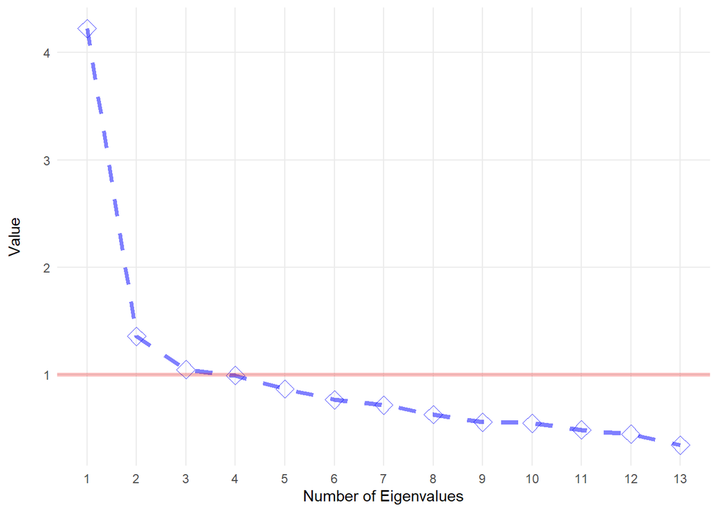

```r
vec_eigen <- eigen(cor(df_soc))$values

tibble(num_eigen = 1:length(vec_eigen),
       eigen_value = vec_eigen) %>%
  ggplot(aes(x = num_eigen, y = eigen_value)) +
  geom_point(size = 4, shape = 5, alpha = .8, color = "blue") +
  geom_line(aes(group = 1), size = 1.5, alpha = 1/2, linetype = 2, color = "blue") +
  geom_hline(yintercept = 1, size = 1.3,
             color = "red2", alpha = 1/4) +
  scale_x_continuous(breaks = 1:13) +
  labs(x = "Number of Eigenvalues", y = "Value\n") +
  theme_minimal() +
  theme(panel.grid.minor = element_blank())
```

Suggests 3 principle components.

### Parallel analysis

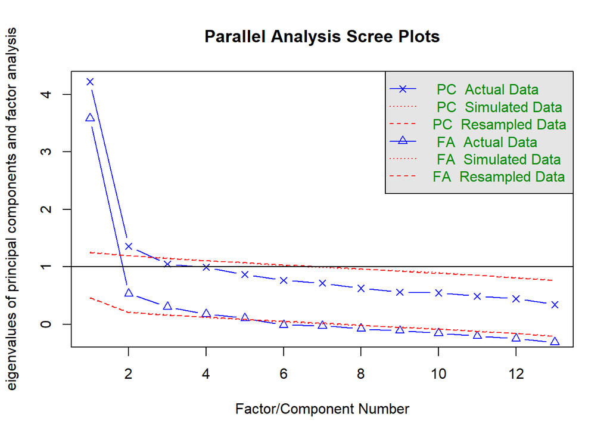

```
Parallel analysis suggests that the number of factors =  5  and the number of components =  2
```

```r
psych::fa.parallel(df_soc)
```

### Exploratory graph analysis (EGA)

EGA Plot

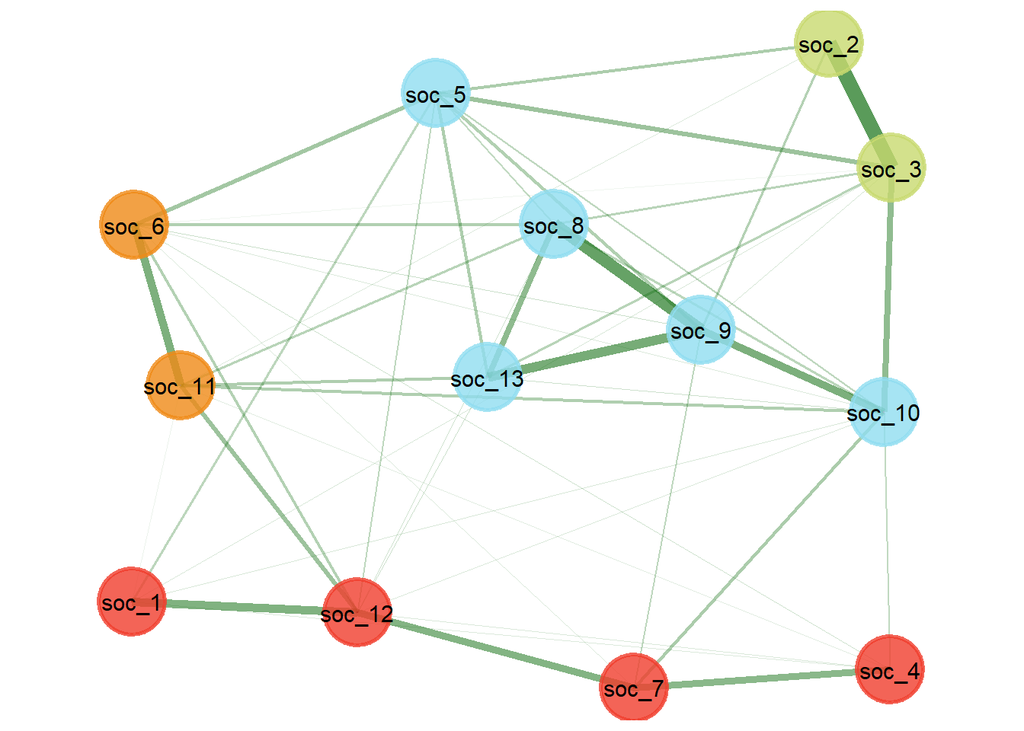

```r
ega$Plot.EGA +
  theme(legend.position = "none")
```

Dimensions from EGA in table form

```r
tbl_ega %>%

  gt::gt() %>%
  gt::opt_table_lines(extent = "none") %>%
  gt::tab_options(
      data_row.padding = gt::px(1),
      heading.border.bottom.width = 2,
      heading.border.bottom.style = "solid",
      table.border.top.color = "white",
      table_body.border.top.width = 1,
      heading.title.font.size = 13,
      table.font.size = 12,
      table_body.border.bottom.width = 1,
      table_body.border.bottom.style = "solid",
      column_labels.border.bottom.style = "solid",
      column_labels.border.bottom.width = 1)
```

| item | dimension | label | subfactor |
| --- | --- | --- | --- |
| soc_1 | 1 | How often do you feel like you don't care what's going on around you? | Meaningfulness |
| soc_4 | 1 | How do you think you will feel about things you will do later, in the future? | Meaningfulness |
| soc_7 | 1 | How do you feel about the things you do every day? | Meaningfulness |
| soc_12 | 1 | How often do you feel that the things you do every day are not so important? | Meaningfulness |
| soc_5 | 2 | How often do you feel that you have been treated unfairly? | Manageability |
| soc_8 | 2 | How often do you not fully understand what you are thinking and feeling? | Comprehensibility |
| soc_9 | 2 | How often do you have feelings that you would rather not have? | Comprehensibility |
| soc_10 | 2 | Many people – even those with strong character – sometimes feel like a failure. How often have you felt this way in the past? | Manageability |
| soc_13 | 2 | How often do you have feelings that you are not sure you can control? | Manageability |
| soc_2 | 3 | How often have you been surprised at the behavior of someone you thought you knew well? | Comprehensibility |
| soc_3 | 3 | How many times has it happened that someone you thought you could rely on disappointed you? | Manageability |
| soc_6 | 4 | How often do you feel that you are in an unfamiliar situation and do not know what to do? | Comprehensibility |
| soc_11 | 4 | How often do you feel like you don't know exactly what is going to happen? | Comprehensibility |

$~$

## Exploratory factor analysis

Below I try a 3-factor solution instead of the 1-factor originally suggested.

```r
fit_3f <- psych::fa(df_soc, nfactors = 3, rotate = "varimax")

summary(fit_3f)
```

```
Factor analysis with Call: psych::fa(r = df_soc, nfactors = 3, rotate = "varimax")

Test of the hypothesis that 3 factors are sufficient.
The degrees of freedom for the model is 42  and the objective function was  0.19
The number of observations was  562  with Chi Square =  105.45  with prob <  2.3e-07

The root mean square of the residuals (RMSA) is  0.03
The df corrected root mean square of the residuals is  0.05

Tucker Lewis Index of factoring reliability =  0.93
RMSEA index =  0.052  and the 10 % confidence intervals are  0.04 0.064
BIC =  -160.47
```

### Factor loadings

```r
fit_3f$Structure
```

```
Loadings:
       MR1   MR3   MR2
soc_1        0.179 0.370
soc_2  0.198 0.652
soc_3  0.321 0.658 0.144
soc_4              0.313
soc_5  0.388 0.394 0.198
soc_6  0.353       0.319
soc_7  0.156       0.403
soc_8  0.701 0.193 0.172
soc_9  0.745 0.263 0.165
soc_10 0.503 0.278 0.300
soc_11 0.342 0.104 0.359
soc_12 0.199       0.608
soc_13 0.595 0.248 0.148

                 MR1   MR3   MR2
SS loadings    2.257 1.316 1.227
Proportion Var 0.174 0.101 0.094
Cumulative Var 0.174 0.275 0.369
```

$~$

### Goodness of fit

```r
anova(cfa_fit, fit_3f)
```

|  | Df | AIC | BIC | Chisq | Chisq diff | Df diff | Pr(>Chisq) |
| --- | --- | --- | --- | --- | --- | --- | --- |
| Saturated | 0 | NA | NA | 0.0000 | NA | NA | NA |
| Model | 65 | NA | NA | 369.8528 | 369.8528 | 65 | 0 |

### Hierarchical factor analysis

The code below is an attempt to fit a structure where the 3 subfactors load onto a higher order single latent factor. This is by all means an overkill considering prior results.

```r
soc_hierarch_formula <- "
SOC_CO =~ soc_2 + soc_6 + soc_8 + soc_9 + soc_11
SOC_MA =~ soc_3 + soc_5 + soc_10 + soc_13
SOC_ME =~ soc_1 + soc_4 + soc_7 + soc_12
SOC_total =~ SOC_CO + SOC_MA + SOC_ME
"

hierarch_fit <- lavaan::sem(soc_hierarch_formula, data = df_soc)

hierarch_summ <-
  summary(hierarch_fit, fit.measures = T)$fit %>%
  as_tibble(rownames = "index") %>%
  mutate(value = round(value, 3)) %>%
  filter(index %in% c("rmsea", "rmsea.ci.lower", "rmsea.ci.upper",
                      "cfi", "pvalue")) %>%
  pivot_wider(values_from = "value", names_from = "index")
```

Summary fit measures:

```r
hierarch_summ %>%
  transmute(CFI = cfi,
            `RMSEA [95%CI]` = paste0(rmsea, " [", rmsea.ci.lower, ", ",
                                     rmsea.ci.upper, "]"),
            `p-value` = pvalue) %>%
  gt::gt()
```

| CFI | RMSEA [95%CI] | p-value |
| --- | --- | --- |
| 0.891 | 0.073 [0.063, 0.083] | 0 |

$~$